# Setting up R projects

Theoretical and Empirical Research Methodology · Implementation Lab 3

Prof. Dr. Claudius Gräbner-Radkowitsch

Europa-University Flensburg, Department of Pluralist Economics

2 October 2026

## Goals for today

1. Learn how to **set up an R project**
2. Learn about the difference between **absolute and relative paths**
3. Learn how to use the **`here` package**

# Part I: Why project management matters

## Our goal

- Learn a **default directory structure**
  - → Facilitates the collaboration with **future-you** considerably
- A general **workflow** that avoids the classic project-management problems

Central idea: all results are **reproducible from the raw data** — and the raw data must never be manipulated

- **Raw data** = what you download from the internet, gather through an experiment, or code yourself

## How to keep your work transparent

Raw data must not be changed — but it is usually not in a state we can work with

1. **Gather** data, save it on your computer
2. **Import** this data into R
3. Write a **script that transforms** raw data into *tidy* data
4. Use the tidy data for further **analysis**: visualisation, modelling, …

Saving the scripts in steps 2 & 3 makes your work fully reproducible — they always tell you what you did to your raw data

## Where we are heading

**Set up your project environment** · *done only once per project*

**Import data** → **transform raw data into tidy data** → **save data** · *may be done several times*

## Where we are heading

**Set up your project environment** · *done only once per project*

**Import data** → **transform raw data into tidy data** → **save data** · *may be done several times*

# Part II: Setting up your R project

## Setting up your working environment

- **Where** you save your data and files matters
- Right **directory structure** as prerequisite for a transparent and reproducible project
- For **every** task in R you should set up your project like this →
- All relevant steps and the rationale described in Gräbner-Radkowitsch (2026)
- ProjectName
  - ProjectName.Rproj
  - data
    - raw
    - tidy
  - R
  - output
  - misc

## Creating an R project

See the **tutorial and the video** for the documentation of the concrete steps

The slides focus on selected background concepts only

# Part III: Paths and the `here` package

## Absolute and relative paths

Two ways to tell your computer where a file is located:

- Via an **absolute path**: the description starts at the root directory 🌲
- Via a **relative path**: the description starts at your current position in the file system

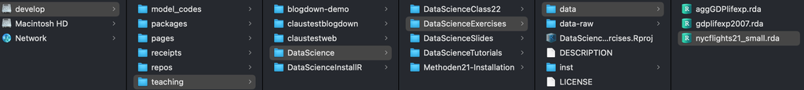

## The same file, two descriptions

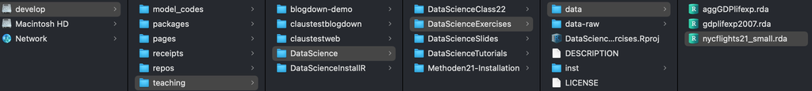

Assuming we are located in `DataScienceExercises` and want to point to `nycflights21_small.rda`:

```r
# absolute
"/Volumes/develop/teaching/DataScience/DataScienceExercises/data/nycflights21_small.rda"

# relative
"data/nycflights21_small.rda"
```

- The relative path is **shorter** …
- … and you can **share code** without forcing others to adjust the path

## Relative paths and `setwd()`

- Problem: how do we set our location to `DataScienceExercises`?
- One option: give `setwd()` the absolute path:

```r
setwd("/Volumes/develop/teaching/DataScience/DataScienceExercises")
```

- Then we can use `"data/nycflights21_small.rda"`
- Many people put `setwd()` at the top of their scripts

[figure not shown]

**But you must never ever do this!**

## Why `setwd()` is evil

- It does not avoid absolute paths — you still have to *provide* an absolute path to `setwd()` 🤯
- It makes others hate you
  - Abby writes `amazing_script.R`

```r
setwd("/Volumes/Macintosh HD/Users/AbbysUserName/PathToFolderThatOnlyExistsHere/ProjectName")
data_file <- data.table::fread("data/file.csv")
```

- Sends it to Ellie who gets:

```r
Error in setwd("/Volumes/Macintosh HD/Users/AbbysUserName/PathToFolderThatOnlyExistsHere/ProjectName") :
  cannot change working directory
```

## The better alternative: `here`

- A simple solution: the package **`here`**
- It sets an **anchor** ⚓ in your project directory
- You then create paths relative to that anchor via `here::here()`
  - Works on **every machine**
- Always put `here::i_am()` into the **first line** of your scripts:

```r
here::i_am("R/my_script.R")
library(here)
library(ggplot2)
# Script content
```

- ProjectName
  - ProjectName.Rproj
  - data
  - R
    - my_script.R
  - output
  - misc

## Your turn

- Create a **new R project** on your computer
- Create all the **required folders**
- Write an **R script**, put it into the right directory, and make it usable for the `here` package
- Check out what `here::here()` returns and experiment with it
- ProjectName
  - ProjectName.Rproj
  - data
    - raw
    - tidy
  - R
  - output
  - misc

## Summary and outlook

- We now know how to organise our **working directory**
- Important difference between **absolute and relative paths**
- The **`here` package** makes code transferable across machines — The better alternative to `setwd()`
- ProjectName
  - ProjectName.Rproj
  - data
    - raw
    - tidy
  - R
  - output
  - misc

Project management is essential, and chronically under-appreciated

**Further topics**: version control (**Git**) · virtual environments (**`renv`**)

## References

Gräbner-Radkowitsch, C. (2026) “Setting Up an R Project” C. Gräbner-Radkowitsch (ed.), *Method and Inquiry*, available at https://euf-methodology-hub.netlify.app/resources/setting-up-an-r-project.